# R for Data Science

- `?geom_smooth`
- Local variable mapping occurs when `mapping = aes()` is placed within geometry function
- Sets aesthetic variables for a single layer
- Becomes useful when multiple layers are used in the same graph

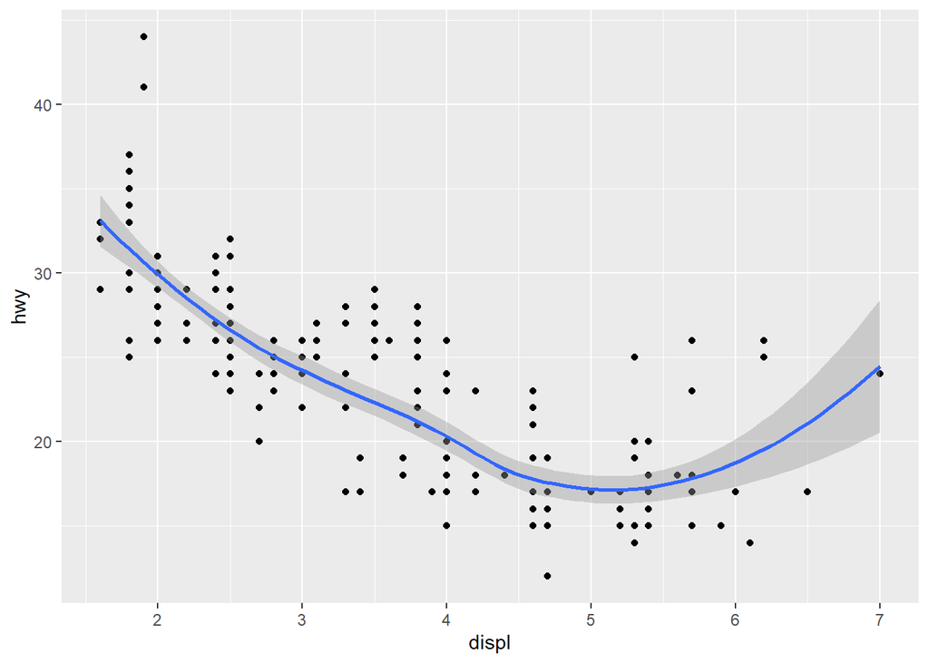

```r
ggplot(data = mpg) +
  geom_point(mapping = aes(x = displ, y = hwy)) +
  geom_smooth(mapping = aes(x = displ, y = hwy))
```

**Global `<MAPPINGS>` with Two `<GEOM_FUNCTION>`**

- Global variable mapping occurs when `mapping = aes()` occurs within the `ggplot()` function
- Sets aesthetic variables for all layers
- Becomes useful when multiple layers are used in the same graph

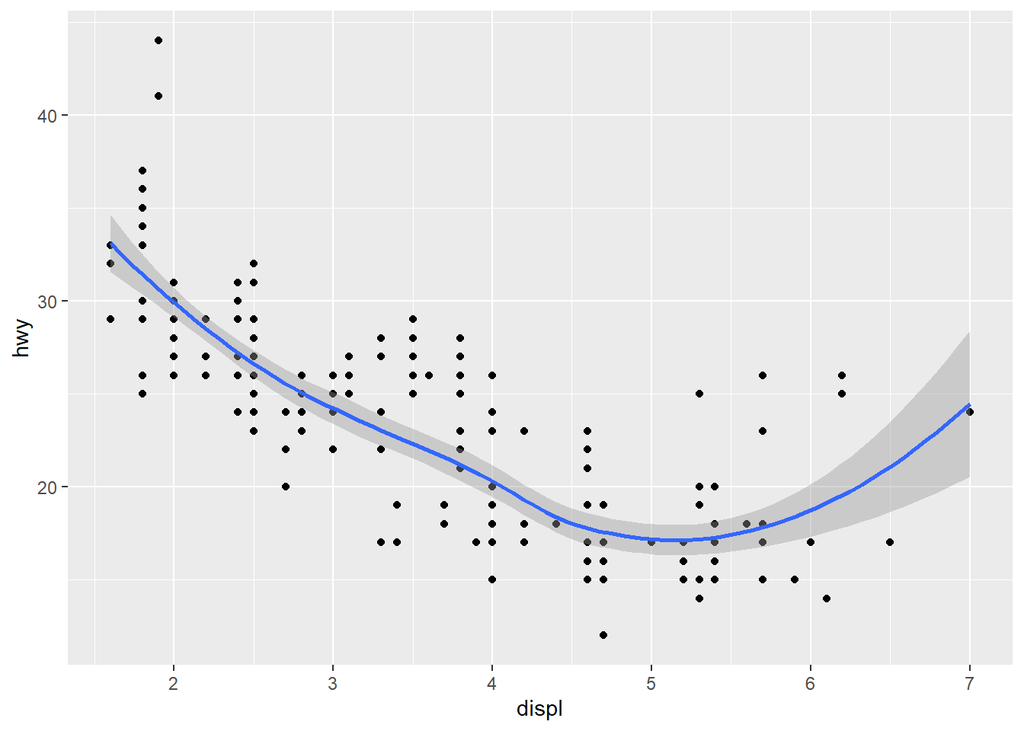

```r
ggplot(data = mpg, mapping = aes(x = displ, y = hwy)) +
  geom_point() +
  geom_smooth()
```

**Local and Global `<MAPPINGS>` with Two `<GEOM_FUNCTION>`**

- Local mapping and global mapping can be mixed
- Local mapping always overrides any global mapping
- Here the `group` overrides the `color` for the smooth line. The smooth line is broken up into 3 lines, one for each drive train type, and not assigned different colors.
- Could also specify data for each geometry

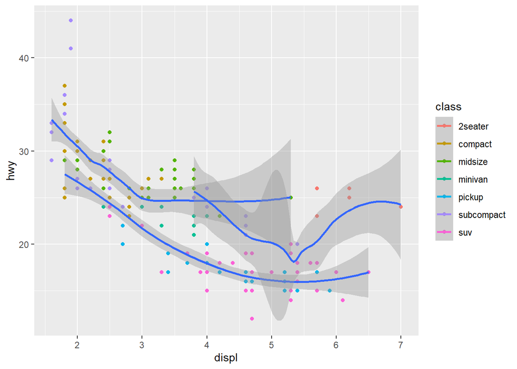

```r
ggplot(data = mpg, mapping = aes(x = displ, y = hwy, color = class)) +
  geom_point() +
  geom_smooth(mapping = aes(group = drv))
```

```r
  0
```

```
#> [1] 0
```

#### Stat

**`<STAT>`**

- This is an example of a statistic transformation. The data is grouped using the `class` variable. Then a new statistic is calculated. The default stat for `geom_bar` is`count`. `count` is used on the y-axis of the bar chart.
- I.e. plot geom, use default stat

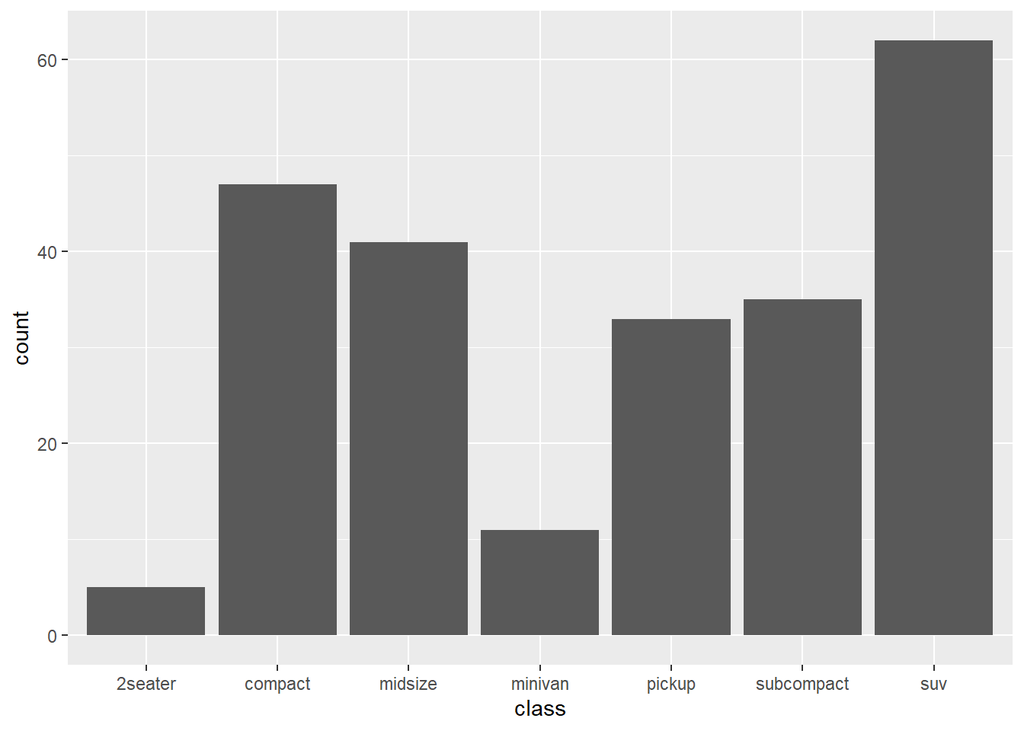

```r
ggplot(data = mpg) +
  geom_bar(mapping = aes(class))
```

- Each geometry has a default stat. Each stat also has a default geometry, so you can plot a stat! Here, we end up creating an identical bar chart to the one above.
- I.e. plot stat, use default geom

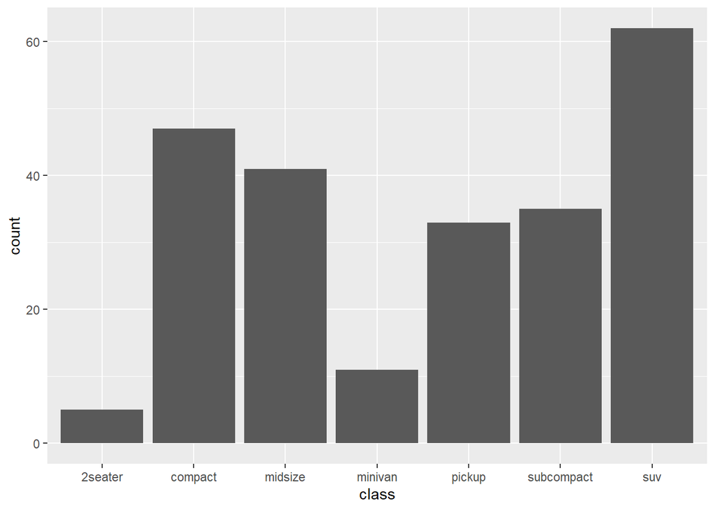

```r
ggplot(data = mpg) +
  stat_count(mapping = aes(class))
```

**`<STAT>` with `stat_summary`**

- `?stat_summary`
- `stat_summary` is used to create many different types of statistical transformations. Its default geometry type is “pointrange”.
- The mappings `fun.ymin`, `fun.ymax`, and `fun.y`have been replaced by `fun.min`, `fun.max`, and `fun` in newer versions of ggplot2
- Below, we plot our stat and then use the default geom

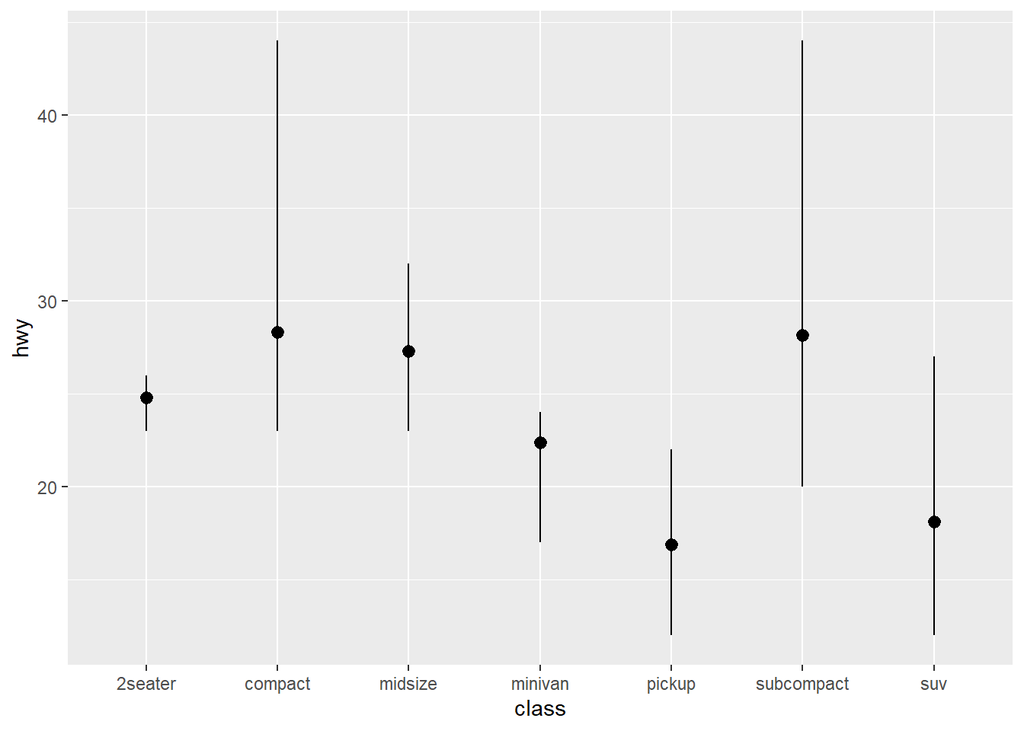

```r
ggplot(data = mpg) +
  stat_summary(
    mapping = aes(x = class, y = hwy),
    fun.min = min,
    fun.max = max,
    fun = mean,
    geom = "pointrange" # Default, so argument not actually needed
  )
```

- We can create the same plot as above by plotting geom and specifying the stat

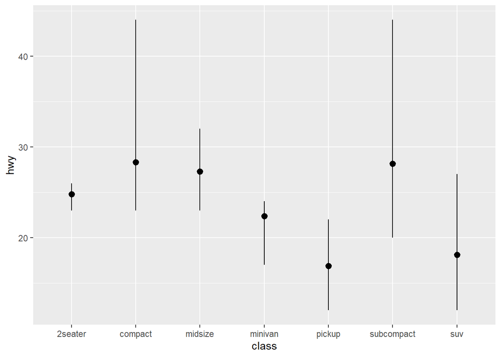

```r
ggplot(data = mpg) +
  geom_pointrange(
    mapping = aes(x = class, y = hwy),
    stat = "summary", # Need this as geom_pointrange default stat is identity
    fun.min = min,
    fun.max = max,
    fun = mean,
      )
```

#### Position

**position = “identity”**

- `?position_identity`
- Does not adjust visual object position. Here, bars for some drive trains are hidden behind taller bars.

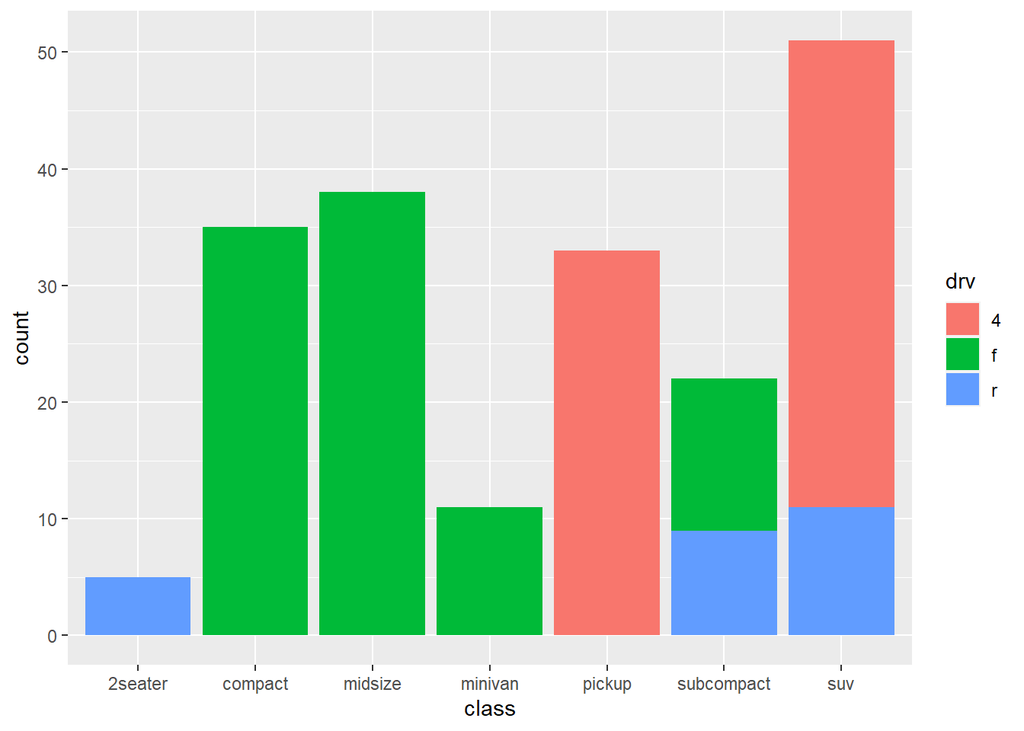

```r
ggplot(data = mpg) +
  geom_bar(
    mapping = aes(x = class, fill = drv),
    position = "identity"
    )
```

**position = “stack”**

- `?position_stack`
- Stacks bars so none are hidden

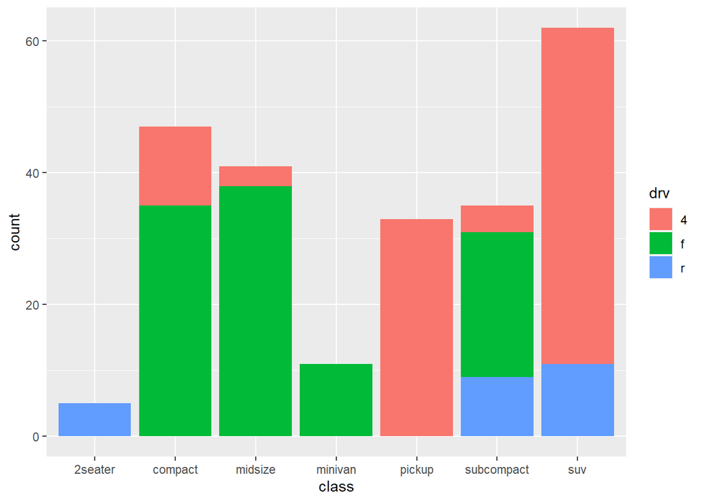

```r
ggplot(data = mpg) +
  geom_bar(
    mapping = aes(x = class, fill = drv),
    position = "stack"
    )
```

**position = “dodge”**

- `?position_dodge`
- Places bars side by side

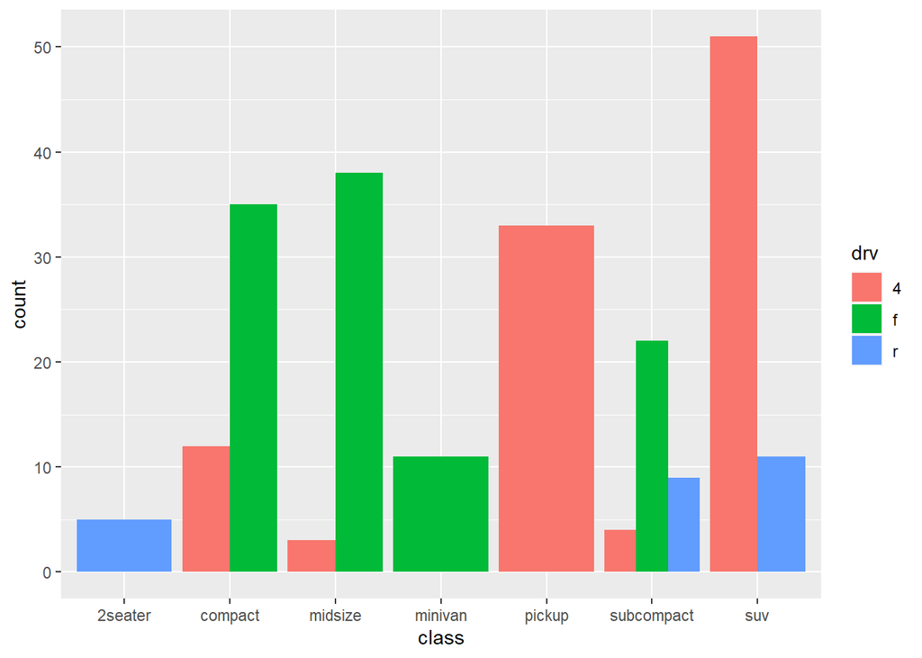

```r
ggplot(data = mpg) +
  geom_bar(
    mapping = aes(x = class, fill = drv),
    position = "dodge"
    )
```

**position = “fill”**

- `?position_fill`
- Stacks bars and standardizes each stack to have constant height. Does so by calculating ratio of `drv` bar to the total bar height for that car `class`, then stacks these values.

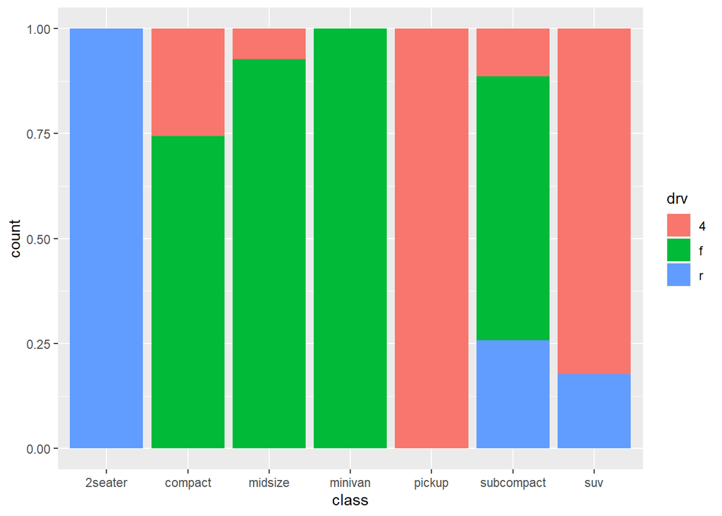

```r
ggplot(data = mpg) +
  geom_bar(
    mapping = aes(x = class, fill = drv),
    position = "fill"
    )
```

**position = “jitter”**

- `?position_jitter`
- Moves all points a small amount in a random direction so that point are not as likely to overlap. Allows you to better see clusters of data.

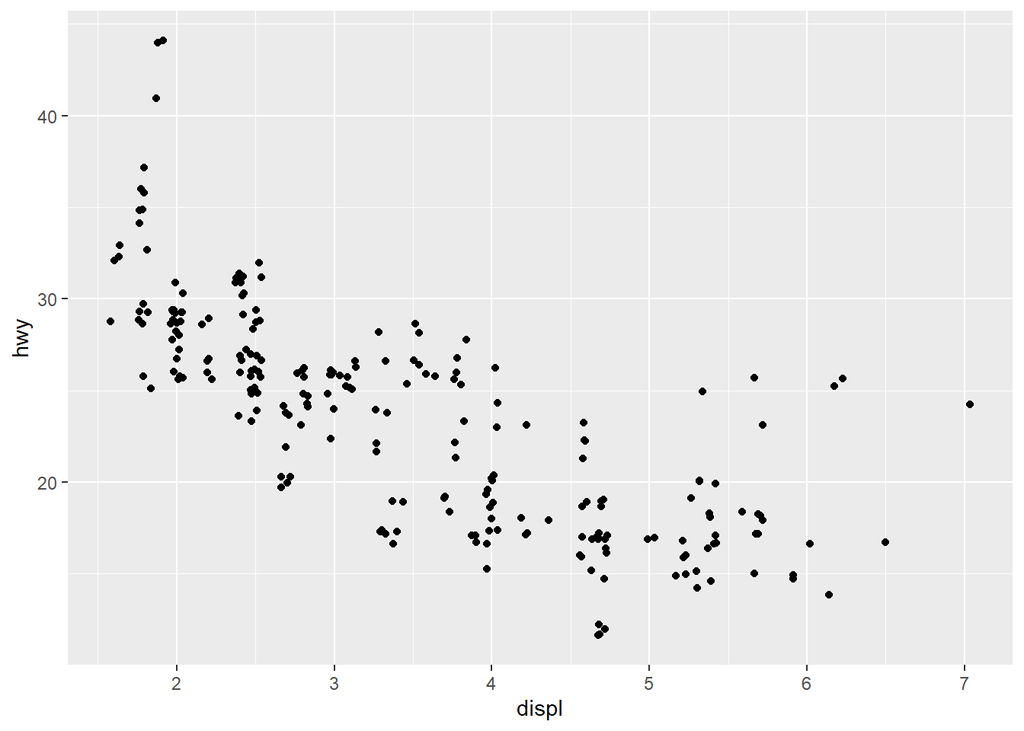

```r
ggplot(data = mpg) +
  geom_point(
    mapping = aes(x = displ, y = hwy),
    position = "jitter"
    )
```

#### Coordinate System

**coord_flip**

- `?coord_flip`
- You may want to flip your x and y axis if the variable names are too long and are hard to read on the x axis. Best to keep variable names going horizontally

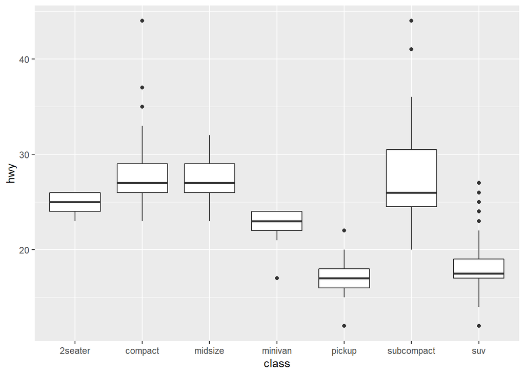

```r
ggplot(data = mpg) +
  geom_boxplot(
    mapping = aes(x = class, y = hwy)
    )
```

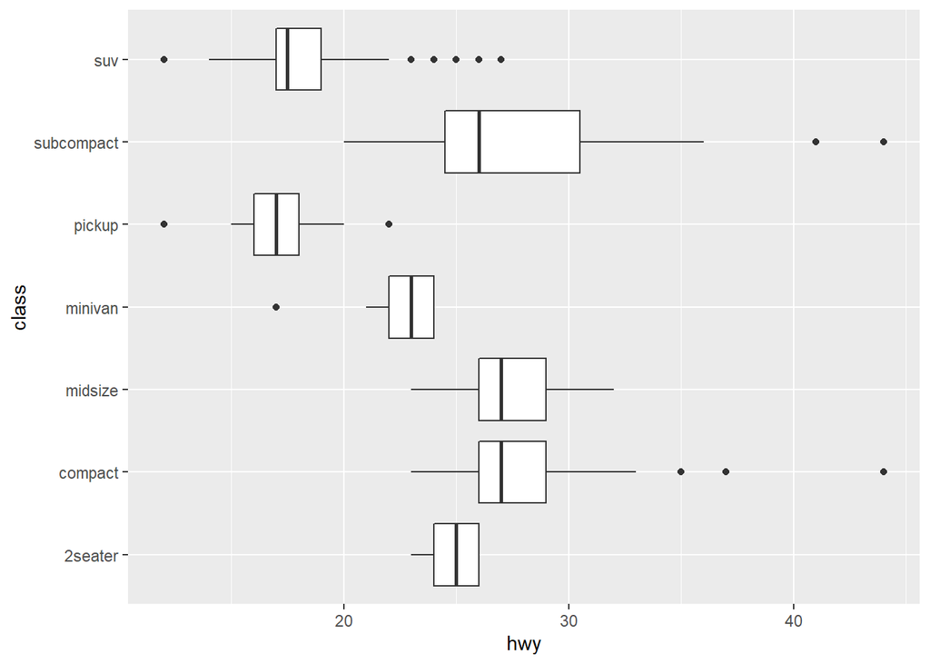

```r
ggplot(data = mpg) +
  geom_boxplot(
    mapping = aes(x = class, y = hwy)
  ) +
  coord_flip()
```

**`<COORDINATE_SYSTEM>` Zoom In**

- Sometimes your plot axes are large to accommodate a large variety of data values. You can manually control the max value of your axes to better visualize certain data values.

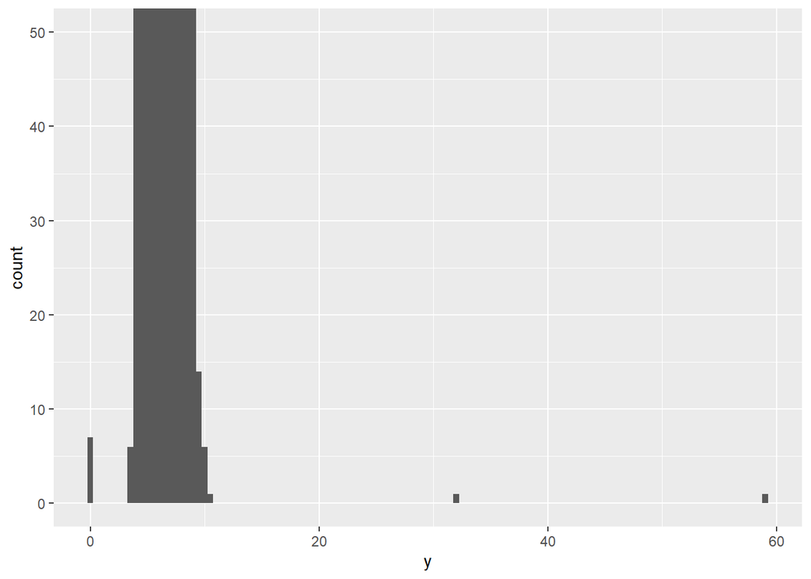

```r
ggplot(diamonds) +
  geom_histogram(mapping = aes(x = y), binwidth = 0.5) +
  coord_cartesian(ylim = c(0,50))
```